# RSF modelis (jaunesni vyrai)

Domantas Gudas

2026-01-14

# 1 Įvadas/kontekstas

Analizavome jaunesnių vyrų klinikinius įrašus, padalijome juos į mokymosi ir testavimo aibes ir pritaikėme atsitiktinių išgyvenamumo miškų (RSF) metodą. Skirtingai nuo standartinės regresijos, šis modelis ieško sudėtingų, netiesinių modelių, kurių tradicinė matematika dažnai nepastebi. Pasirinkau šį metodą, nes paprastas atsitiktinių miškų algoritmas neparodė gerų rezultatų. Naudojame ne tik mirties įvykį, bet šiuo atveju ir turime informaciją apie dienas iki įvykio, todėl modelis gavosi geresnis. Taip pat galėsime kalbėti ne tik apie mirtį, bet apie išgyvenamumo riziką.

Taip pat padariau sprendimą, kad šioms duomenų grupėms (jaun. vyrai, jaun. moterys, vyr. vyrai, vyr. moterys) konstruosime 2 modelius. Vieną be hospitalizacijų ir amžiaus, kitą su. Logika maždaug tokia, kad norime pasižiūrėti, kiek įtakos turi šie kintamieji, ir ar modelis nėra tiesiog prastas ir sprendžia viską apie žmones iš amžiaus ir kiek kartų ligoninėje guli. Norisi, kad esamos ligos pasakytų apie žmogaus būklę, o ne jo amžius ar hospitalizacijos. Pagal rezultatus, modelis neblogas ir be šių kintamųjų.

# 2 Bibliotekos

# 3 Duomenų užsikrovimas

# 4 Duomenų paruošimas

# 5 Mokymo/testavimo aibės

# 6 Modelio apmokymas

# 7 Konkordacija

| Concordance (C-Index) = 0.719 |
| --- |

Tai yra modelio „tikslumo įvertinimas“. C indeksas (Konkordacija), lygus 0.719, reiškia, kad jei atsitiktinai pasirenkame du pacientus, modelis teisingai nustato, kuris iš jų mirs pirmas, maždaug 72 % atvejų. Modeliavime rodiklis, viršijantis 0,7, laikomas naudingu įrankiu.

# 8 Kintamųjų svarba

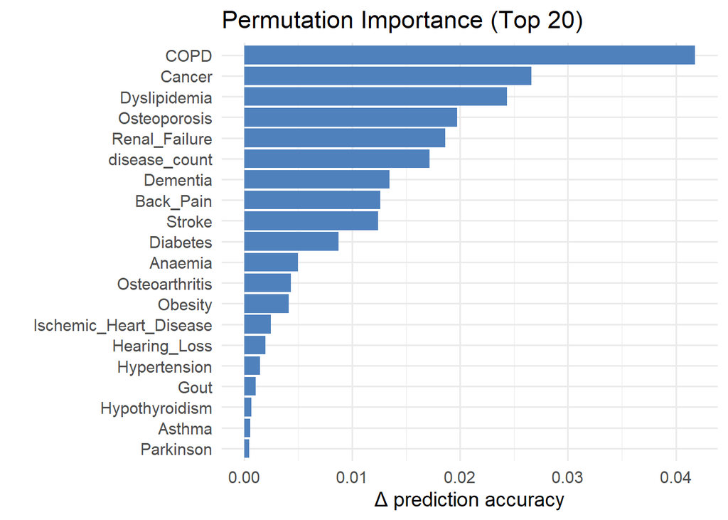

# 9 Kaplan-Meier

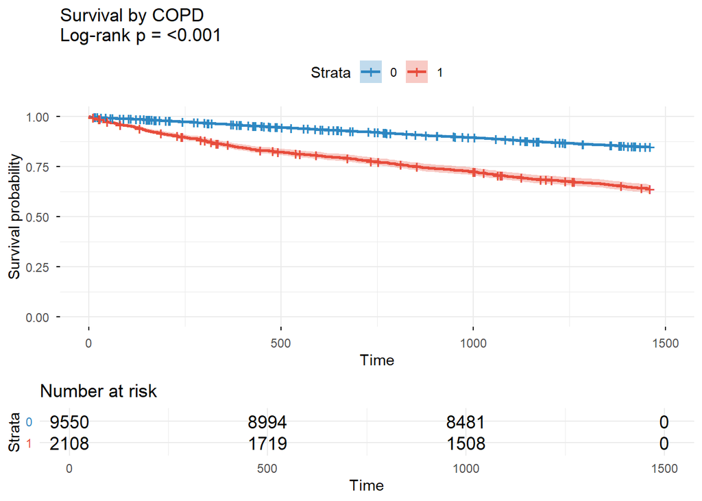

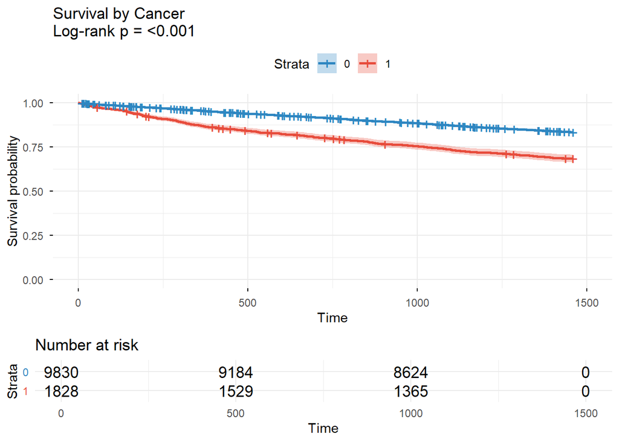

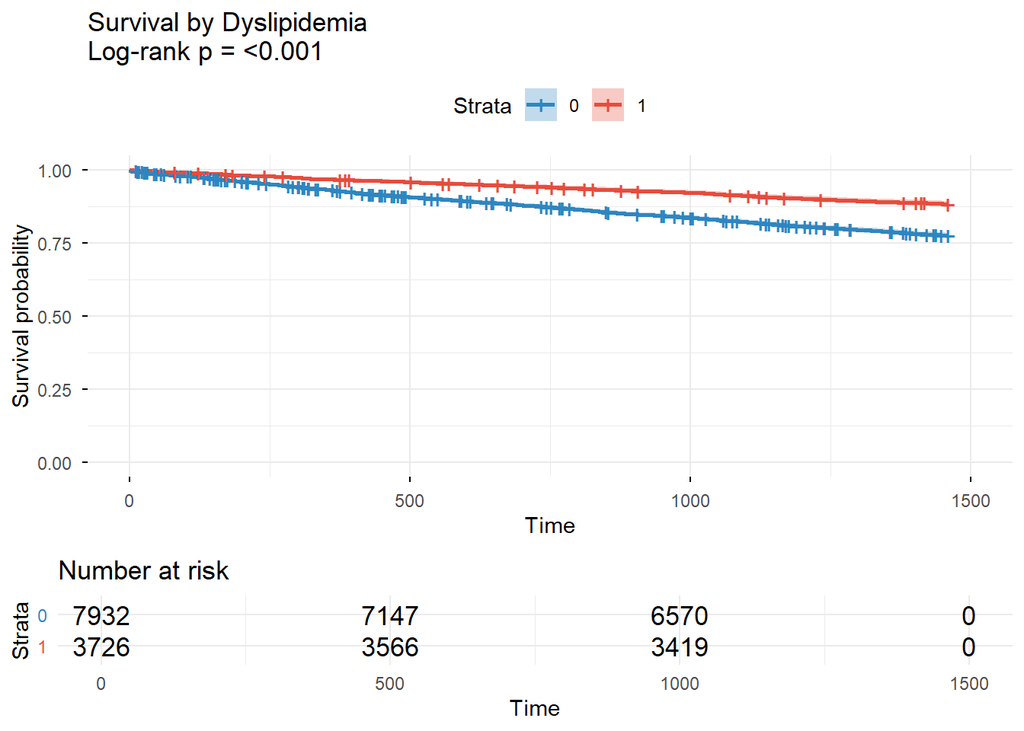

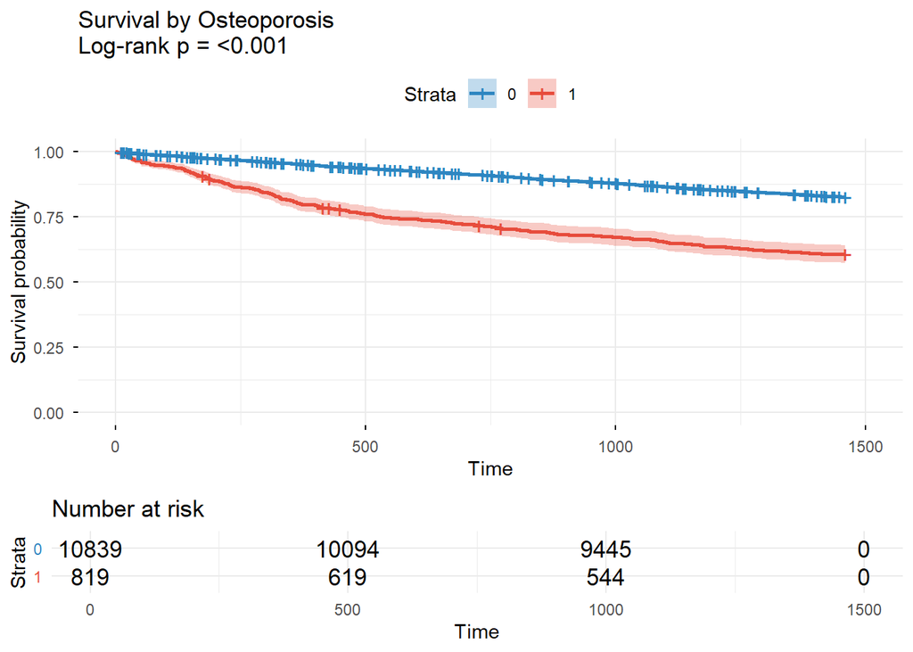

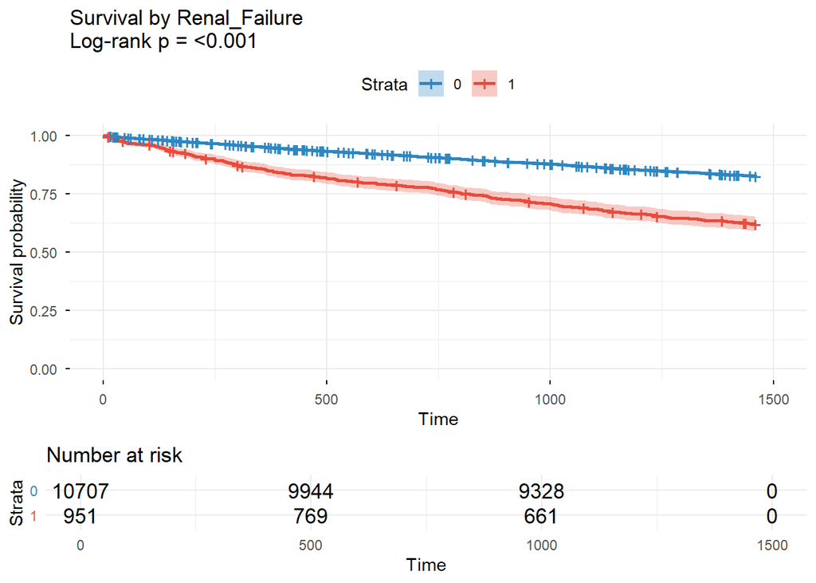

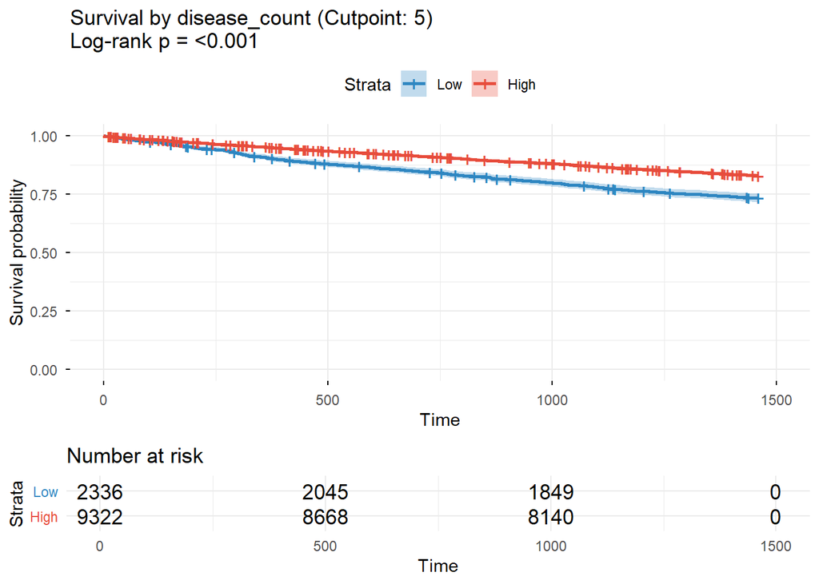

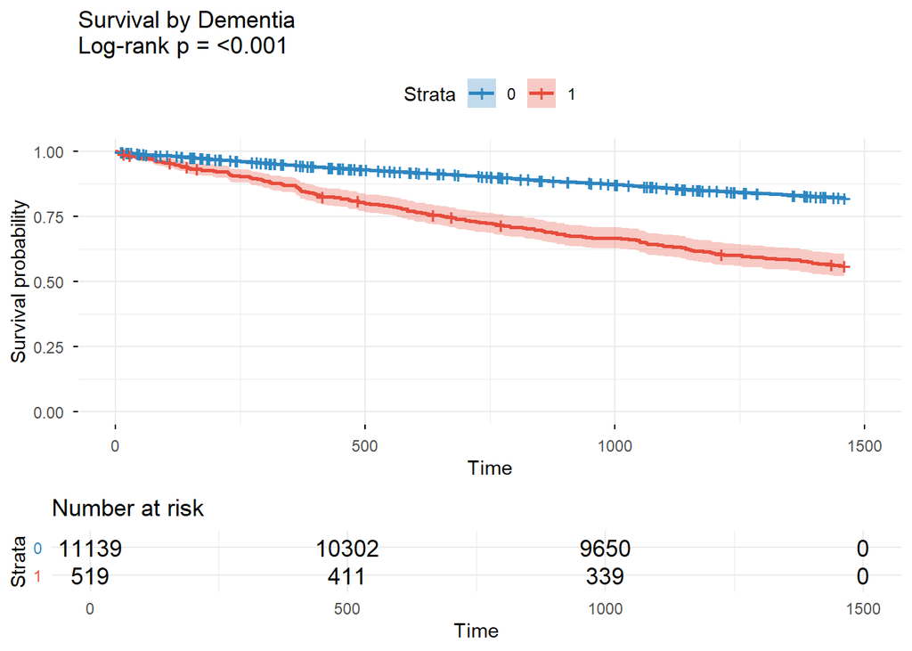

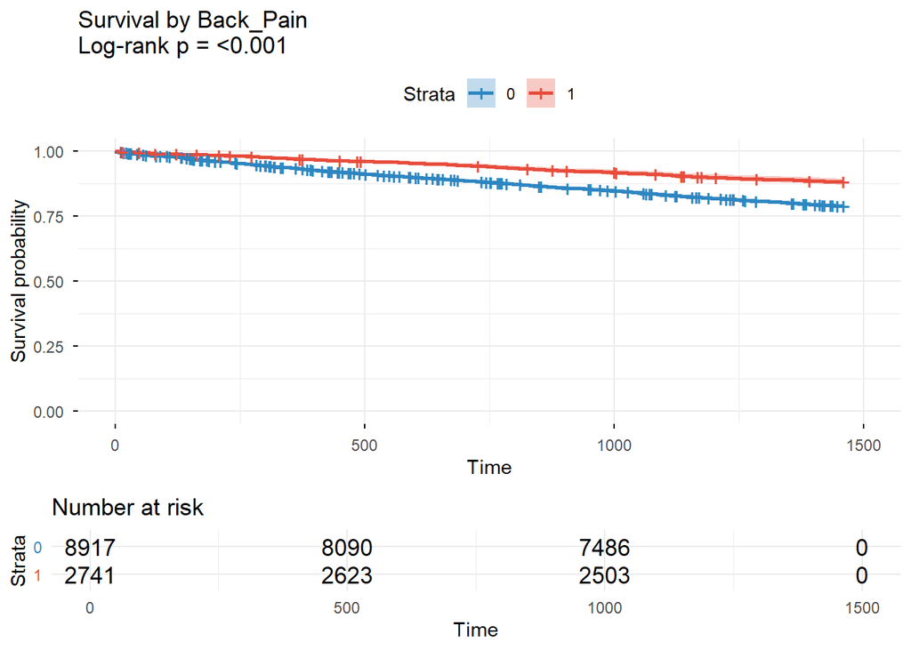

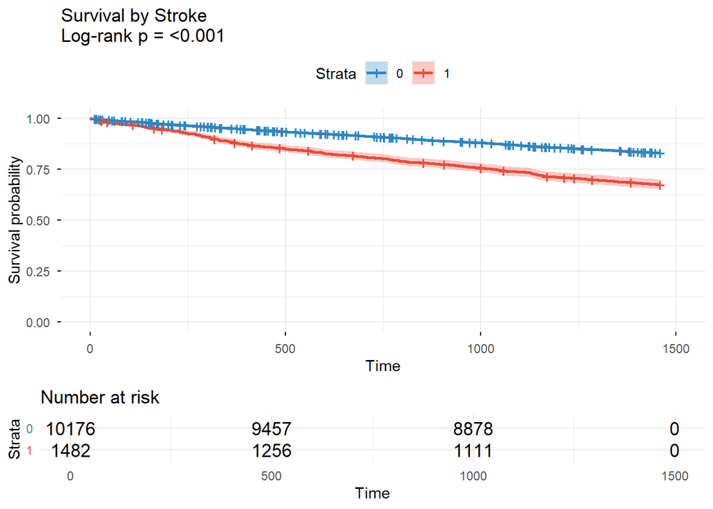

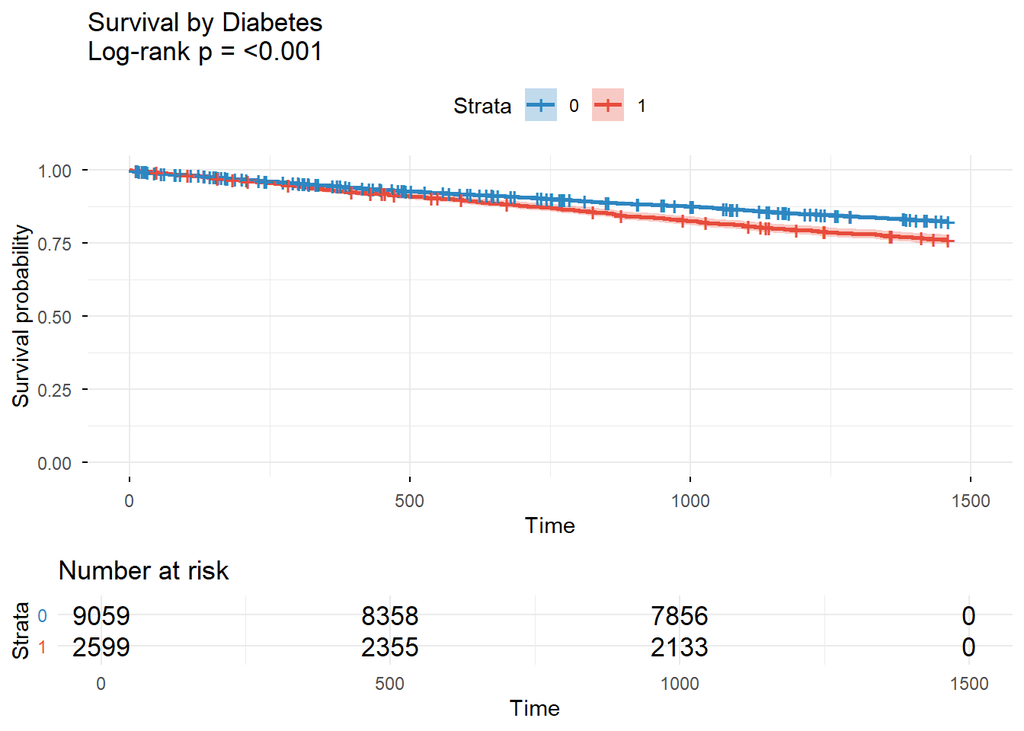

# 10 KM grafikas pagal rizikos kvartilius

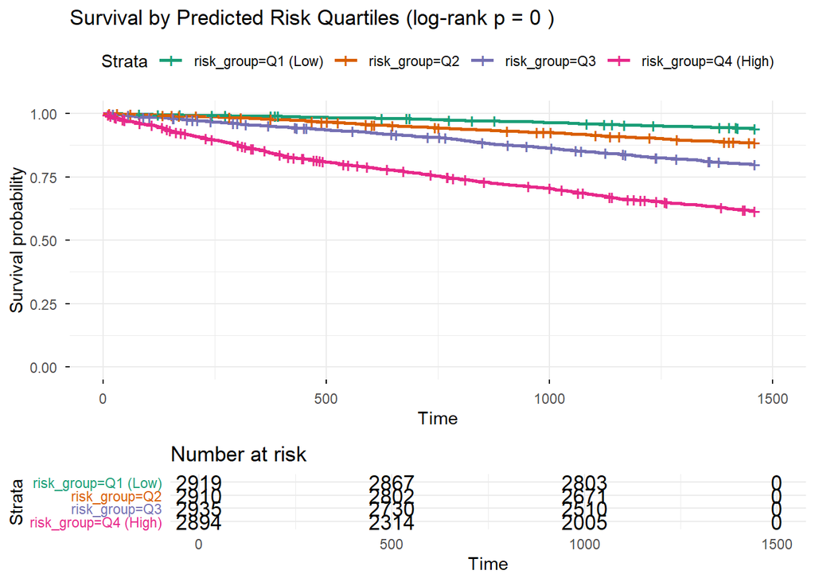

Mes įvertinome, kurios ligos agresyviausiai didina mirtingumą. Tada pacientus suskirstėme į keturis „rizikos kvartilius“. Kaplan-Meier (KM) grafikas vizualiai patvirtina modelio veikimą: „didelės rizikos“ grupėje (25 proc. viršutinės pacientų grupės) išgyvenamumas sumažėjo žymiai labiau, palyginti su „mažos rizikos“ grupe.

# 11 Nuo laiko priklausantys AUC

Performance Summary: Time-Dependent Discrimination Power

|  | Follow-up Interval | Days | Area Under the Curve (AUC) |
| --- | --- | --- | --- |
| t=365 | 1 Year | 365 | 0.789 |
| t=730 | 2 Years | 730 | 0.761 |
| t=1095 | 3 Years | 1095 | 0.745 |
| t=1459 | 4 Years | 1459 | 0.736 |

Note:  
AUC values represent the model’s ability to distinguish between survivors and non-survivors at specific time points.

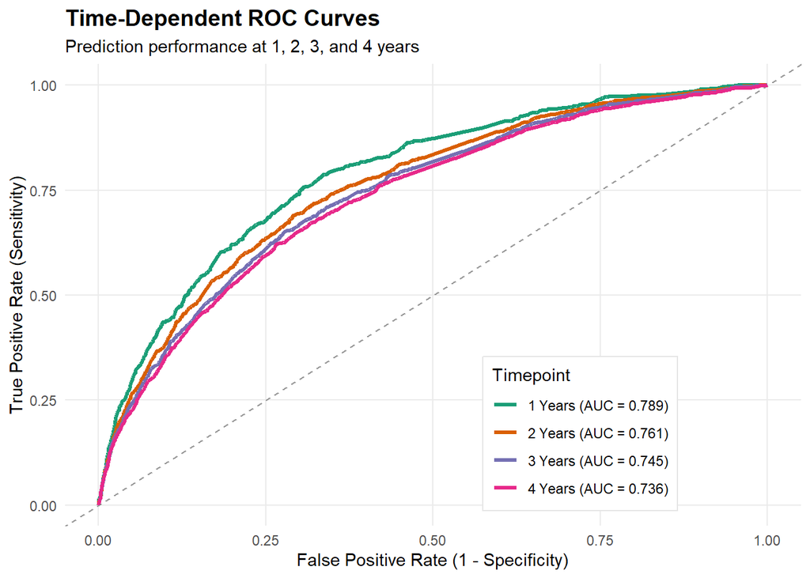

Tai rodo, kaip gerai modelis atskiria riziką konkrečiais laiko momentais.

1 metai (0,789): modelis išskirtinai gerai nustato trumpalaikę mirtingumo riziką.

4 metai (0,736): nors našumas šiek tiek sumažėja, bet išlieka patikimas ilgalaikei prognozei.

# 12 Kalibracijos grafikai (1-4 metai)

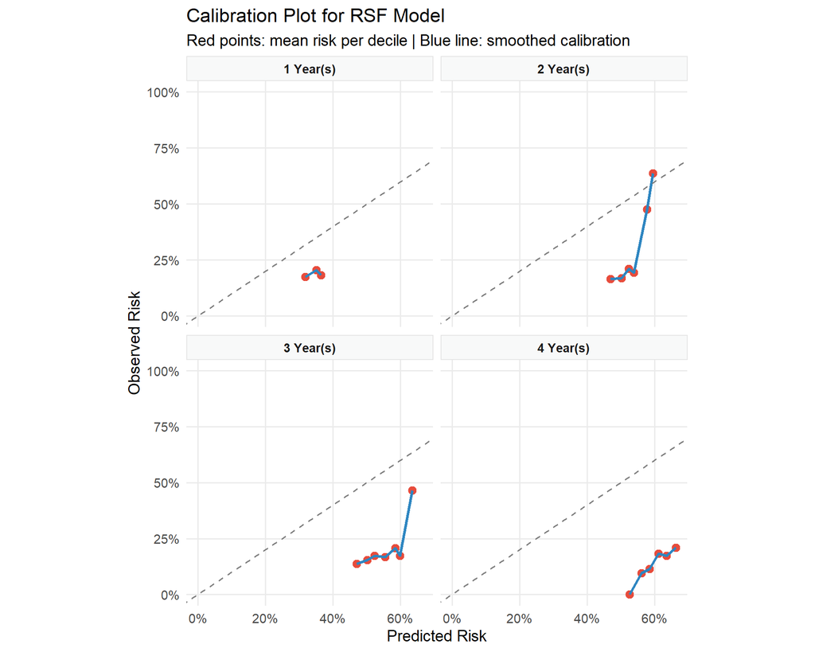

Modelis prastai atspėja tikslų procentą. Jis gali teigti, kad pacientui A yra „60 % mirties rizika“, kai iš tikrųjų tokie pacientai kaip jis miršta tik 40 % atvejų. Modelis yra reikšmes sudėjo apačioje įstrižainės, tai reiškia, kad jis pervertina riziką. (Jis prognozuoja didelę riziką, bet iš tikrųjų miršta mažiau žmonių). Jei būtų reikšmės virš įstrižainės, būtų atvirkščiai. Geriausiai sukalibruoto modelio reikšmes būtų kartu su įstrižaine. Modelis labai gerai nustato, kam kyla didelė rizika (didelis AUC), tačiau konkretūs procentiniai skaičiai (pvz., „12 % rizika“) turėtų būti traktuojami kaip rizikos balas, o ne tiksli tikimybė.

# 13 Standartinis Cox model

Multivariable Cox Proportional Hazards Regression Results

| Variable | Effect Size HR | Confidence Interval 95% CI Lower | Confidence Interval 95% CI Upper | Significance p-value |
| --- | --- | --- | --- | --- |
| COPD | 2.54 | 2.37 | 2.71 | < 0.001 *** |
| Cancer | 1.53 | 1.41 | 1.65 | < 0.001 *** |
| Dyslipidemia | 0.59 | 0.54 | 0.64 | < 0.001 *** |
| Osteoporosis | 2.07 | 1.88 | 2.27 | < 0.001 *** |
| Renal_Failure | 2.26 | 2.09 | 2.46 | < 0.001 *** |
| disease_count | 0.96 | 0.94 | 0.99 | 0.002 ** |
| Dementia | 2.46 | 2.24 | 2.71 | < 0.001 *** |
| Back_Pain | 0.66 | 0.61 | 0.72 | < 0.001 *** |
| Stroke | 1.74 | 1.61 | 1.87 | < 0.001 *** |
| Diabetes | 1.36 | 1.27 | 1.46 | < 0.001 *** |

Note:  
* p < 0.05, ** p < 0.01, *** p < 0.001. HR = Hazard Ratio.

# 14 Cox modelio prielaidos

Schoenfeld Residuals Test for Proportional Hazards Assumption

| Variable | Chi_Square | p-value | Status |
| --- | --- | --- | --- |
| COPD | 33.565 | < 0.001 | ✘ Fail (Violated) |
| Cancer | 32.571 | < 0.001 | ✘ Fail (Violated) |
| Dyslipidemia | 6.234 | 0.013 | ✘ Fail (Violated) |
| Osteoporosis | 85.002 | < 0.001 | ✘ Fail (Violated) |
| Renal_Failure | 1.952 | 0.162 | ✔ Pass (Proportional) |
| disease_count | 0.820 | 0.365 | ✔ Pass (Proportional) |
| Dementia | 1.408 | 0.235 | ✔ Pass (Proportional) |
| Back_Pain | 0.710 | 0.399 | ✔ Pass (Proportional) |
| Stroke | 0.539 | 0.463 | ✔ Pass (Proportional) |
| Diabetes | 16.200 | < 0.001 | ✘ Fail (Violated) |
| GLOBAL | 152.788 | < 0.001 | ✘ Fail (Violated) |

Palyginome savo dirbtinio intelekto modelį su „senuoju standartu“ (Kokso regresija).

Prielaidų patenkinti visų nepavyko.

Reikšmė: Šis „nesėkmė“ įrodo, kad su šiomis ligomis susijusi rizika nėra pastovi – ji kinta pacientui senstant arba ligai progresuojant. Būtent todėl naudojome Atsitiktinio miško modelį; jis apdoroja šiuos „pažeidėjus“ ten, kur standartinė statistika neveikia.

# 15 Laiko priklausomi kintamieji (Time-Varying Effects)

Final Clinical Model: Constant Hazard Ratios & Time-Varying Slopes

| Variable | Effect Type | HR (95% CI) or Slope | Significance |
| --- | --- | --- | --- |
| Renal_Failure | Constant | 2.23 (2.05-2.41) | < 0.001 *** |
| disease_count | Constant | 0.98 (0.96-1.01) | 0.129 |
| Dementia | Constant | 2.43 (2.21-2.67) | < 0.001 *** |
| Back_Pain | Constant | 0.64 (0.59-0.69) | < 0.001 *** |
| Stroke | Constant | 1.7 (1.58-1.83) | < 0.001 *** |
| COPD | Time-varying (log(t+1)) | 0.139 | < 0.001 *** |
| Cancer | Time-varying (log(t+1)) | 0.063 | < 0.001 *** |
| Dyslipidemia | Time-varying (log(t+1)) | -0.086 | < 0.001 *** |
| Osteoporosis | Time-varying (log(t+1)) | 0.104 | < 0.001 *** |
| Diabetes | Time-varying (log(t+1)) | 0.047 | < 0.001 *** |

Note:  
For ‘Constant’ variables, the value represents the Hazard Ratio. For ‘Time-varying’ variables, the value represents the interaction slope with log(time); positive values indicate risk increases over time.

# 16 AFT

Exponentiated AFT Model Coefficients (Weibull vs Lognormal)

|  | Variable | Weibull | Lognormal |
| --- | --- | --- | --- |
| COPD | COPD | 0.380 | 0.300 |
| Cancer | Cancer | 0.643 | 0.580 |
| Dyslipidemia | Dyslipidemia | 1.735 | 1.863 |
| Osteoporosis | Osteoporosis | 0.469 | 0.354 |
| Renal_Failure | Renal_Failure | 0.428 | 0.344 |
| disease_count | disease_count | 1.041 | 1.056 |
| Dementia | Dementia | 0.392 | 0.310 |
| Back_Pain | Back_Pain | 1.538 | 1.578 |
| Stroke | Stroke | 0.563 | 0.484 |
| Diabetes | Diabetes | 0.726 | 0.678 |

Tai yra AFT modelis. Užuot prognozavęs mirties pavojų, jis prognozuoja, kiek liga sutrumpina arba pailgina gyvenimo trukmę. Mes galime pasirinkti du šio modelio skirtingus skirstinius (weibull ir log-normal)

Weibull AFT prielaida: Rizika: Daroma prielaida, kad pavojaus dažnis yra monotoniškas (visada didėjantis, mažėjantis arba pastovus). Naudojimas: Geriausia, kai pavojaus dažnis neturi konkretaus piko, o vėliau krenta.

Logaritminio normalaus AFT skirstinio prielaida: Rizika: Įtraukia nemonotoninius rizikos rodiklius (pvz., rizika iš pradžių didėja, o vėliau mažėja, kaip ir daugelyje klinikinių tyrimų). Duomenų forma: Idealiai tinka iškreiptiems duomenims su ilgomis uodegomis (didelė dispersija / standartinis nuokrypis).

# 17 Išvados

Taikėme daugiau įvairių modelių dėl to, kad bandyti pagrįsti, kad ką gavome nėra atsitiktinis rezultatas. Būtų faina, jei Cox modelio prielaidos būtų patenkintos ir galėtume tiesiogiai interpretuoti savo rezultatą, bet deja taip nėra(išskyrus kintamuosius, kurie patenkino prielaidą), todėl bandome tai pagrįsti kitokiais metodais. Visų modelių rezultatai yra sutampantys: Osteoperosis, Renal Failure, Stroke ir kiti rodikliai rodo didesnę išgyvenamumo riziką asmenims, kurie yra <= 75 metų vyrai su ŠN. Labai gerai, kad galime interpretuoti Renal Failure, Stroke ir Dementia riziką tikrais skaičiais (HR). Apie kitus kintamuosius dėja, galime tik pasakyti, kaip kinta laike, bet bazinės rizikos nežinome.